# Causal Inference and SEM: Lab 3 - Applications

Noémi Schuurman, Oisín Ryan, and Ellen Hamaker

March 2022

# 1. Simpsons Paradox, Berksons Paradox, Selection Bias

In the following exercises you will practice recognizing/analyzing/visualizing variables in the context of Simpsons Paradox and Berksons Paradox (Berksons Bias). All of the data were simulated.

The data can be found in `DataEx1Lab3.Rdata`.

$\blacktriangleright$ Load the data.

```r
load('dataEx1Lab3.Rdata')
```

## 1.1 Observational Data 1 - “High IQ Makes Students Lazy!?!”

Researchers have measured three variables for university students: Their study success after three bachelor years (higher scores indicate more success), study hours (amount of hours put into study per week on average), and their IQ scores.

They want to evaluate if the IQ score of students affects how many of hours they study on average per week.

$\blacktriangleright$ Based on the description above, what do you believe is the most reasonable causal model (DAG) for these data?

$\blacktriangleright$ Take a look at the dataframe `study_succes_data`. In the following analyses, use hours of study as your dependent variable.

## 1.1.1 Simpsons Paradox

$\blacktriangleright$ Use linear regression to evaluate marginal association between hours of study and IQ scores.

```r
studyh_marg <- lm(studyhours~IQ,data=study_succes_data)
summary(studyh_marg)
```

```
##
## Call:
## lm(formula = studyhours ~ IQ, data = study_succes_data)
##
## Residuals:
##      Min       1Q   Median       3Q      Max
## -14.3849  -3.2664  -0.1033   3.2087  15.3351
##
## Coefficients:
##              Estimate Std. Error t value Pr(>|t|)
## (Intercept) 30.503053   3.343853   9.122   <2e-16 ***
## IQ          -0.007098   0.029100  -0.244    0.807
## ---
## Signif. codes:  0 '***' 0.001 '**' 0.01 '*' 0.05 '.' 0.1 ' ' 1
##
## Residual standard error: 4.978 on 598 degrees of freedom
## Multiple R-squared:  9.948e-05,  Adjusted R-squared:  -0.001573
## F-statistic: 0.05949 on 1 and 598 DF,  p-value: 0.8074
```

$\blacktriangleright$ How can the regression coefficient you obtain be interpreted? What would your conclusion be if you interpreted these results in a causal manner?

$\blacktriangleright$ Use linear regression to evaluate the association between hours of study and IQ scores, conditional on study success.

```r
studyh_cond <- lm(studyhours~IQ+studysucces,data=study_succes_data)
summary(studyh_cond)
```

```
##
## Call:
## lm(formula = studyhours ~ IQ + studysucces, data = study_succes_data)
##
## Residuals:
##     Min      1Q  Median      3Q     Max
## -8.9836 -2.0394  0.0952  2.0404  8.9153
##
## Coefficients:
##             Estimate Std. Error t value Pr(>|t|)
## (Intercept) -3.26619    2.35996  -1.384    0.167
## IQ          -0.10562    0.01844  -5.727 1.62e-08 ***
## studysucces  0.49773    0.01625  30.636  < 2e-16 ***
## ---
## Signif. codes:  0 '***' 0.001 '**' 0.01 '*' 0.05 '.' 0.1 ' ' 1
##
## Residual standard error: 3.107 on 597 degrees of freedom
## Multiple R-squared:  0.6113, Adjusted R-squared:   0.61
## F-statistic: 469.4 on 2 and 597 DF,  p-value: < 2.2e-16
```

$\blacktriangleright$ How can the regression coefficient you obtain be interpreted? What would your conclusion be if you interpreted these results in a causal manner?

$\blacktriangleright$ How do you explain the results of the above two analyses? Given your initial DAG and the results of the analyses, what do you think is the most reasonable conclusion?

## 1.1.2 Berksons Bias

Imagine a research team collecting the same data - but instead of the population of students as a whole they focused on students that are in the running for ‘honors’ or even a ‘cum laude’ diploma. These are students that have a higher study success than 95. They only directly measured IQ scores and the average hours of study per week.

$\blacktriangleright$ Select a sample from the original dataset with only students in the running for a honors or cum laude diploma.

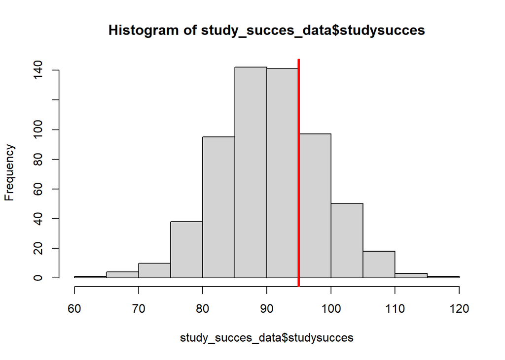

```r
hist(study_succes_data$studysucces)
abline(v=95, col="red", lwd=3)
```

```r
honors_data = study_succes_data[which(study_succes_data$studysucces>95),]
```

$\blacktriangleright$ Use linear regression to evaluate the association between hours of study and IQ scores. Interpret the results, and compare them to the previous two analyses.

```r
studyh_honors <- lm(studyhours~IQ,data=honors_data)
summary(studyh_honors)
```

```
##
## Call:
## lm(formula = studyhours ~ IQ, data = honors_data)
##
## Residuals:
##     Min      1Q  Median      3Q     Max
## -9.6753 -2.3922  0.1916  2.3506 11.3520
##
## Coefficients:
##             Estimate Std. Error t value Pr(>|t|)
## (Intercept) 43.76814    4.58928   9.537   <2e-16 ***
## IQ          -0.07944    0.03953  -2.009   0.0461 *
## ---
## Signif. codes:  0 '***' 0.001 '**' 0.01 '*' 0.05 '.' 0.1 ' ' 1
##
## Residual standard error: 3.608 on 167 degrees of freedom
## Multiple R-squared:  0.02361,    Adjusted R-squared:  0.01776
## F-statistic: 4.038 on 1 and 167 DF,  p-value: 0.04611
```

## 1.1.3 Visualize

$\blacktriangleright$ Make a scatterplot in which you visualize the marginal relationship between hours of study and IQ scores, for the whole student population (e.g., not conditioning on study success in any way).

$\blacktriangleright$ Make another scatterplot in which you visualize the relationship between hours of study and IQ scores, for the potential cum laude students. (or add this to the previous scatterplot)

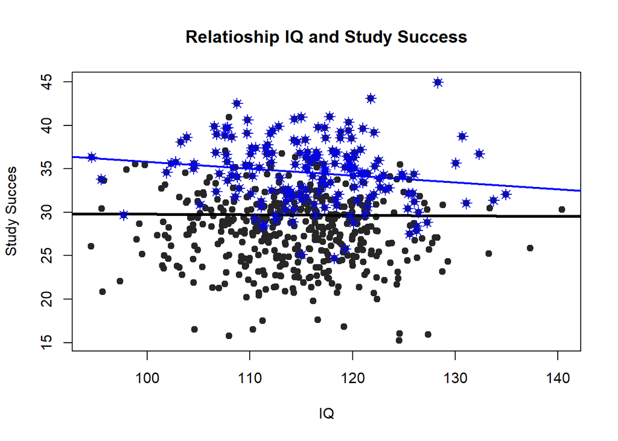

```r
plot(study_succes_data$IQ, study_succes_data$studyhours, main = "Relatioship IQ and Study Success", ylab="Study Succes", xlab="IQ", pch=19, col="grey15")
abline(a = studyh_marg$coefficients[1] , b = studyh_marg$coefficients[2], col = "black",lwd=3)

points(honors_data$IQ, honors_data$studyhours, pch=8,col="blue",cex=1.2)
abline(a = studyh_honors $coefficients[1] , b = studyh_honors $coefficients[2], col = "blue", lwd=2)

####

#Or, to visualize the effect of conditioning on Study Succes in more of a continuous fashion
library(ggplot2)
```

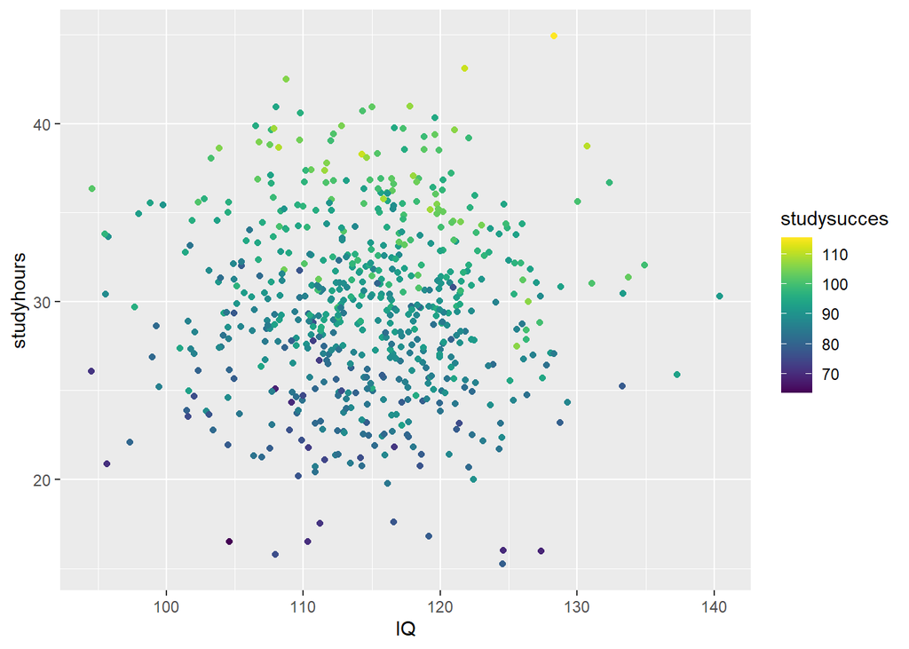

```r
library(viridis)
# Gradient color
ggplot(study_succes_data, aes(x = IQ, y = studyhours, colour = studysucces)) +
  geom_point()+
  scale_color_viridis(option = "D")
```

## 1.1.4 The true average causal effect

The data was simulated in the following way:

```r
set.seed(113221701) # set the seed for comparison
n <- 600          # total sample size
IQ <- rnorm(n,115,7)
studyhours<- rnorm(n,30,5)
studysucces<- 25 + .25*IQ + 1.25*studyhours + rnorm(n,0,5)
```

$\blacktriangleright$ What is the true average causal effect? Calculate this by mimicking an intervention: Determine the expected value of the dependent variable while you fix the cause variable to zero, and determine the expected value of the dependent variable while you fix the cause variable to one. Then calculate the ACE.

```r
###IQ set to 1###
IQ <- 1
EVstudyhours_IQ1 <- 30
EVstudysucces <- 25 + .25*IQ + 1.25*EVstudyhours_IQ1

###IQ set to 1###
IQ <- 0
EVstudyhours_IQ0<- 30
EVstudysucces <- 25 + .25*IQ + 1.25*EVstudyhours_IQ0

EVstudyhours_IQ1-EVstudyhours_IQ0
```

```
## [1] 0
```

## 1.2 Observational Data 2 - “Does Size Matter?”

In this exercise we loosely mimick a classic (real research) example of simpsons paradox, where two treatments (cause variables of interest) for kidney stones were evaluated. The outcome variable of interest is a measurement recovery/health/wellbeing, and a potential covariate to consider is kidney stone size. It is observational data: People come in with kidney stone problems, and are assigned treatment. After treatment, their wellbeing is measured.

$\blacktriangleright$ Based on the description above, what do you believe is the most reasonable causal model (DAG) for these data?

$\blacktriangleright$ Take a look at the dataframe `kidneystone_data`.

## 1.2.1 Simpsons Paradox or Berksons Bias

$\blacktriangleright$ Use linear regression to uncover either an example of Simpsons Paradox or Berksons Bias (your choice). Discuss the results.

```r
#simpsons#
wellb_marg <- lm(wellbeing~treatment,data=kidneystone_data)
summary(wellb_marg)
```

```
##
## Call:
## lm(formula = wellbeing ~ treatment, data = kidneystone_data)
##
## Residuals:
##     Min      1Q  Median      3Q     Max
## -5.6558 -1.8821 -0.4212  1.9130 11.2518
##
## Coefficients:
##             Estimate Std. Error t value Pr(>|t|)
## (Intercept)  15.9355     0.1401  113.77   <2e-16 ***
## treatment    -4.4220     0.2524  -17.52   <2e-16 ***
## ---
## Signif. codes:  0 '***' 0.001 '**' 0.01 '*' 0.05 '.' 0.1 ' ' 1
##
## Residual standard error: 2.605 on 498 degrees of freedom
## Multiple R-squared:  0.3813, Adjusted R-squared:  0.3801
## F-statistic:   307 on 1 and 498 DF,  p-value: < 2.2e-16
```

```r
wellb_cond <- lm(wellbeing~treatment+stonesize,data=kidneystone_data)
summary(wellb_cond)
```

```
##
## Call:
## lm(formula = wellbeing ~ treatment + stonesize, data = kidneystone_data)
##
## Residuals:
##      Min       1Q   Median       3Q      Max
## -2.60895 -0.75667  0.00616  0.71325  3.03285
##
## Coefficients:
##             Estimate Std. Error t value Pr(>|t|)
## (Intercept) 29.76371    0.27639  107.69   <2e-16 ***
## treatment    1.81421    0.15845   11.45   <2e-16 ***
## stonesize   -1.96950    0.03855  -51.09   <2e-16 ***
## ---
## Signif. codes:  0 '***' 0.001 '**' 0.01 '*' 0.05 '.' 0.1 ' ' 1
##
## Residual standard error: 1.043 on 497 degrees of freedom
## Multiple R-squared:  0.9011, Adjusted R-squared:  0.9007
## F-statistic:  2263 on 2 and 497 DF,  p-value: < 2.2e-16
```

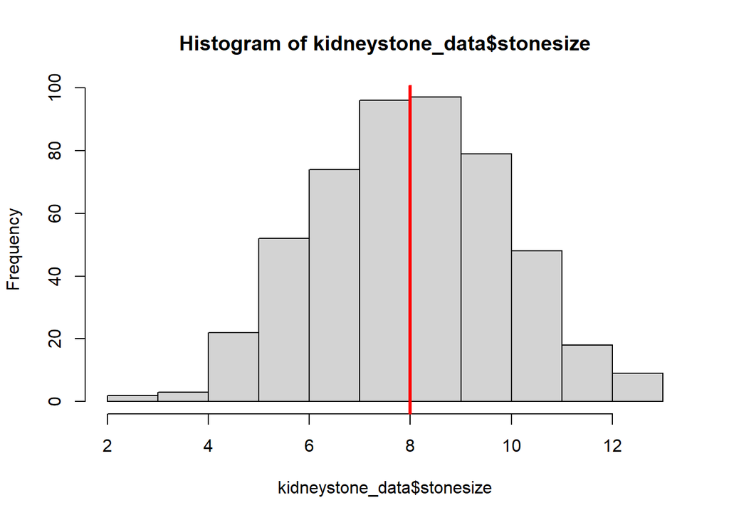

```r
#Berksons. In the example below, we select for people that have kidneystones larger than 8 mm (but you may select in different ways, of course, and this may alter the results).

hist(kidneystone_data$stonesize)
abline(v=8, col="red", lwd=3)
```

```r
larges_data = kidneystone_data[which(kidneystone_data$stonesize>8),]

wellb_larges <- lm(wellbeing~treatment,data=larges_data)
summary(wellb_larges)
```

```
##
## Call:
## lm(formula = wellbeing ~ treatment, data = larges_data)
##
## Residuals:
##     Min      1Q  Median      3Q     Max
## -5.6558 -1.0791  0.0669  1.2510  4.2217
##
## Coefficients:
##             Estimate Std. Error t value Pr(>|t|)
## (Intercept)  13.1346     0.1830  71.766  < 2e-16 ***
## treatment    -1.6212     0.2337  -6.938 3.41e-11 ***
## ---
## Signif. codes:  0 '***' 0.001 '**' 0.01 '*' 0.05 '.' 0.1 ' ' 1
##
## Residual standard error: 1.803 on 249 degrees of freedom
## Multiple R-squared:  0.162,  Adjusted R-squared:  0.1586
## F-statistic: 48.14 on 1 and 249 DF,  p-value: 3.414e-11
```

## 1.2.2 Visualize

$\blacktriangleright$ Use scatterplots to illustrate the Paradox.

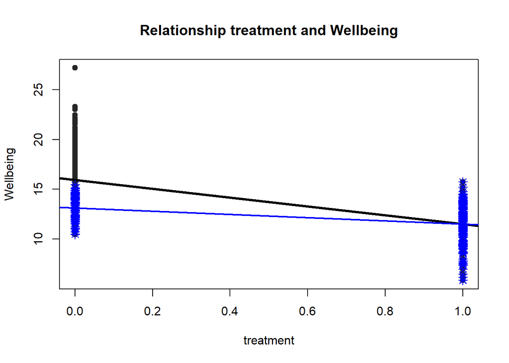

```r
plot(kidneystone_data$treatment, kidneystone_data$wellbeing, main = "Relationship treatment and Wellbeing", ylab="Wellbeing", xlab="treatment", pch=19, col="grey15")
abline(a = wellb_marg$coefficients[1] , b = wellb_marg$coefficients[2], col = "black",lwd=3)

points(larges_data$treatment, larges_data$wellbeing, pch=8,col="blue",cex=1.2)
abline(a = wellb_larges$coefficients[1] , b = wellb_larges$coefficients[2], col = "blue", lwd=2)
```

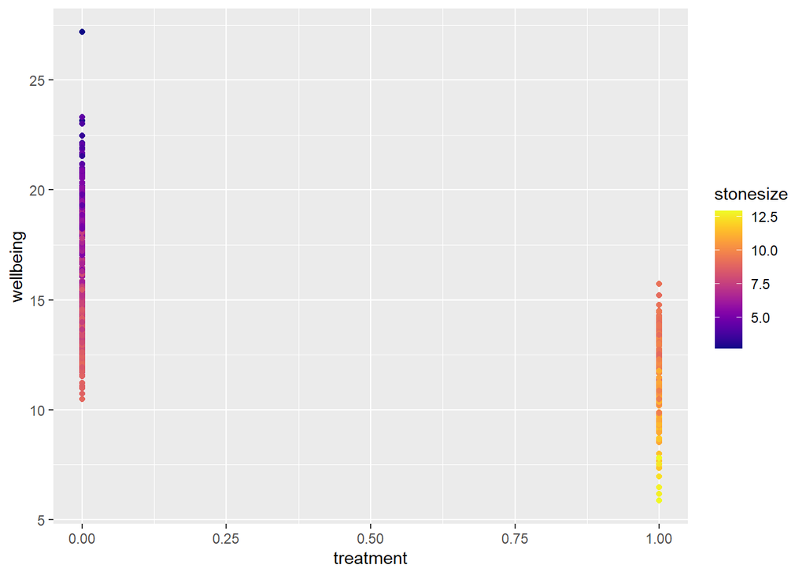

```r
#Optional, to visualize the effect of conditioning on Study Succes in more of a continuous fashion
library(ggplot2)
library(viridis)
# Gradient color
ggplot(kidneystone_data, aes(x = treatment, y = wellbeing, colour = stonesize)) +
  geom_point()+
  scale_color_viridis(option = "C")
```

## 1.2.3 The true average causal effect

The data was simulated in the following way:

```r
set.seed(133222032) # set the seed for comparison
n <- 500          # total sample size
stonesize <- rnorm(n,8,2) # averge stone size of 8 mm (yikes)
treatment=rep(0,n)
treatment[which(stonesize>9)] <- 1  #Treatment is assigned deterministically (no probability involved here) completely based on stone size. People with large stones (>9) get treatment '1'.
wellbeing <- 30 + 2*treatment - 2*stonesize + rnorm(n,0,1)
```

$\blacktriangleright$ Calculate the true causal effect by mimicking an intervention. Discuss the results.

```r
###Treatment = 1###
stonesize_EV <- 8 # averge stone size of 8 mm (yikes)
treatment=1
wellbeing_t1_EV <- 30 + 2*treatment - 2*stonesize_EV

###Treatment = 0###
stonesize_EV <- 8 # averge stone size of 8 mm (yikes)
treatment=0
wellbeing_t0_EV <- 30 + 2*treatment - 2*stonesize_EV

wellbeing_t1_EV-wellbeing_t0_EV
```

```
## [1] 2
```

## 1.3 Observational Data 3 - “Does length matter?”

In this exercise consider a (simulated) study on the amount of pollen flowers receive (outcome of interest) from pollinators, given their sepal length (potential cause of interest) and a general measure of bloom attractiveness (third variable). It is observational data.

$\blacktriangleright$ Based on the description above, what do you believe is the most reasonable causal model (DAG) for these data?

$\blacktriangleright$ Take a look at the dataframe `pollen_data`.

## 1.3.1 Simpsons Paradox or Berksons Bias

$\blacktriangleright$ Use linear regression to uncover either an example of Simpsons Paradox or Berksons Bias (your choice). Discuss the results.

```r
#simpsons#
pollen_marg <- lm(pollen~sepal_length,data=pollen_data)
summary(pollen_marg)
```

```
##
## Call:
## lm(formula = pollen ~ sepal_length, data = pollen_data)
##
## Residuals:
##      Min       1Q   Median       3Q      Max
## -0.41156 -0.07373  0.00051  0.07480  0.34329
##
## Coefficients:
##              Estimate Std. Error t value Pr(>|t|)
## (Intercept)  0.524290   0.025516   20.55   <2e-16 ***
## sepal_length 0.106500   0.005029   21.18   <2e-16 ***
## ---
## Signif. codes:  0 '***' 0.001 '**' 0.01 '*' 0.05 '.' 0.1 ' ' 1
##
## Residual standard error: 0.1132 on 498 degrees of freedom
## Multiple R-squared:  0.4739, Adjusted R-squared:  0.4728
## F-statistic: 448.5 on 1 and 498 DF,  p-value: < 2.2e-16
```

```r
pollen_cond <- lm(pollen~sepal_length+bloom_attract,data=pollen_data)
summary(pollen_cond)
```

```
##
## Call:
## lm(formula = pollen ~ sepal_length + bloom_attract, data = pollen_data)
##
## Residuals:
##      Min       1Q   Median       3Q      Max
## -0.17273 -0.03699 -0.00053  0.03640  0.18137
##
## Coefficients:
##                Estimate Std. Error t value Pr(>|t|)
## (Intercept)   0.0051951  0.0169807   0.306   0.7598
## sepal_length  0.0071709  0.0032970   2.175   0.0301 *
## bloom_attract 0.0201787  0.0004733  42.632   <2e-16 ***
## ---
## Signif. codes:  0 '***' 0.001 '**' 0.01 '*' 0.05 '.' 0.1 ' ' 1
##
## Residual standard error: 0.05252 on 497 degrees of freedom
## Multiple R-squared:  0.887,  Adjusted R-squared:  0.8866
## F-statistic:  1951 on 2 and 497 DF,  p-value: < 2.2e-16
```

```r
#Berksons. In the example below, we select for flowers that have bloom attractiveness higher than 50 (but you may select in different ways, of course, and this may alter the results).

quantile(pollen_data$bloom_attract, probs = seq(0, 1, 0.1), na.rm = FALSE,
         names = TRUE, type = 7)
```

```
##       0%      10%      20%      30%      40%      50%      60%      70%
## 29.28626 40.98337 44.51708 47.12024 49.03087 50.64113 52.18181 54.07859
##      80%      90%     100%
## 55.82669 58.50389 70.03212
```

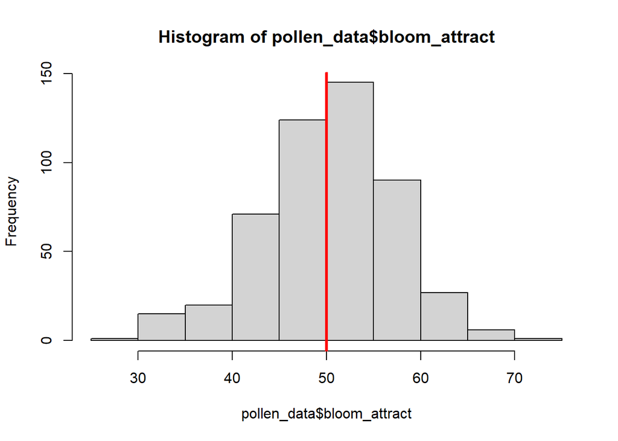

```r
hist(pollen_data$bloom_attract)
abline(v=50, col="red", lwd=3)
```

```r
highatt_data = pollen_data[which(pollen_data$bloom_attract>50),]

pollen_highatt <- lm(pollen~sepal_length,data=highatt_data)
summary(pollen_highatt)
```

```
##
## Call:
## lm(formula = pollen ~ sepal_length, data = highatt_data)
##
## Residuals:
##       Min        1Q    Median        3Q       Max
## -0.269887 -0.054109 -0.004626  0.050222  0.255858
##
## Coefficients:
##              Estimate Std. Error t value Pr(>|t|)
## (Intercept)   0.85303    0.03574  23.871  < 2e-16 ***
## sepal_length  0.05609    0.00643   8.724 2.95e-16 ***
## ---
## Signif. codes:  0 '***' 0.001 '**' 0.01 '*' 0.05 '.' 0.1 ' ' 1
##
## Residual standard error: 0.08601 on 267 degrees of freedom
## Multiple R-squared:  0.2218, Adjusted R-squared:  0.2189
## F-statistic:  76.1 on 1 and 267 DF,  p-value: 2.954e-16
```

## 1.3.2 Visualize

$\blacktriangleright$ Use scatterplots to illustrate the Paradox.

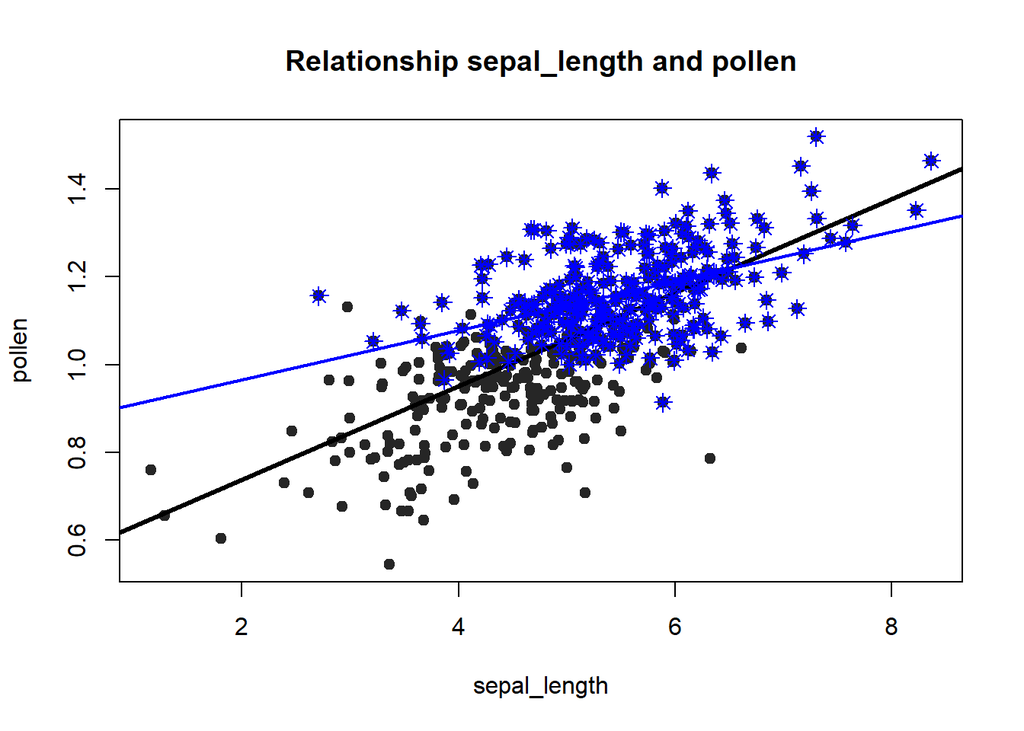

```r
plot(pollen_data$sepal_length, pollen_data$pollen, main = "Relationship sepal_length and pollen", ylab="pollen", xlab="sepal_length", pch=19, col="grey15")
abline(a = pollen_marg$coefficients[1] , b = pollen_marg$coefficients[2], col = "black",lwd=3)

points(highatt_data$sepal_length, highatt_data$pollen, pch=8,col="blue",cex=1.2)
abline(a = pollen_highatt$coefficients[1] , b = pollen_highatt$coefficients[2], col = "blue", lwd=2)
```

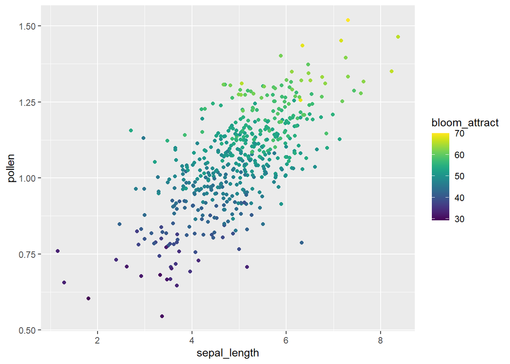

```r
#Optional, to visualize the effect of conditioning on Study Succes in more of a continuous fashion
library(ggplot2)
library(viridis)
# Gradient color
ggplot(pollen_data, aes(x = sepal_length, y = pollen, colour = bloom_attract)) +
  geom_point()+
  scale_color_viridis(option = "D")
```

## 1.3.3 The true average causal effect

The data was simulated in the following way:

```r
set.seed(133222058) # set the seed for comparison
n <- 500          # total sample size
sepal_length <- rnorm(n,5,1)
bloom_attract= 25+5*sepal_length + rnorm(n,0,5)
pollen <- 0 + .02*bloom_attract + .01*sepal_length + rnorm(n,0,.05)
```

$\blacktriangleright$ Calculate the true causal effect by mimicking an intervention. Discuss the results.

```r
###sepal_length = 1###
sepal_length <-1
bloom_attract_EV_sl1= 25+5*sepal_length
pollen_EV_sl1 <- 0 + .02*bloom_attract_EV_sl1 + .01*sepal_length

###sepal_length = 0###
sepal_length <-0
bloom_attract_EV_sl0= 25+5*sepal_length
pollen_EV_sl0 <- 0 + .02*bloom_attract_EV_sl0 + .01*sepal_length

pollen_EV_sl1-pollen_EV_sl0
```

```
## [1] 0.11
```

# 2. Controlling for Pretests, ANCOVA, Change Scores

This exercise will help you to better understanding of the effects of controlling for pre-tests and the relation between ANCOVA approaches and Change-score approaches. In this exercise you will practice with different scenarios (or data generating mechanisms) that give rise to data in which there is an outcome variable Y2, a (binary) treatment variable X, and a covariate Y1 that is a previous measurement of the same variable as the outcome variable.

The scenarios under which we generate data are:

- a randomized controlled trial (RCT), in which treatment assignment X is independent of pretest Y1
- a scenario in which treatment groups X already existed prior to the pretest Y1, such that the pretest is a mediator
- a scenario in which treatment assignment X is entirely based on the pretest score Y1, such that the pretest is a confounder
- a scenario in which treatment assignment X is partly based on the pretest score Y1, such that the pretest is a confounder

In each scenario, the data for the outcome variables Y2 are simulated using the regression model: $Y_{2i} = \beta_0 + \beta_1 X_i + \beta_2 Y_{1i} + e_i$. The *key difference* between these scenarios is in *how* and *why* treatment X and pretest Y1 are related.

For each dataset, you will then estimate four models:

- an ANCOVA model with the posttest score Y2 as the outcome: $Y_{2i} = \beta_0 + \beta_1 X_i + \beta_2 Y_{1i} + e_i$
- an ANCOVA model with the gain score G=Y2-Y1 as the outcome (in other words, a change score model where we control for pre-test): $Y_{2i} - Y_{1i} = \beta_0 + \beta_1 X_i + (\beta_2-1) Y_{1i} + e_i$
- a change score model with only $X$ as a predictor: $Y_{2i} - Y_{1i} = \gamma_0 + \gamma_1 X_i + e_i$
- a marginal model in which Y1 is not included: $Y_{2i} = \phi_0 + \phi_1 X_i + e_i$

## 2.1 RCT

We begin with simulating data according to an RCT. This implies that treatment X and pretest Y1 are independent of each other, while the posttest Y2 may depend on both.

The DAG for this model looks like this:

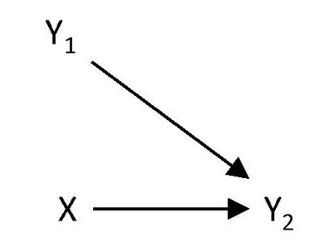

*Fig.1a: DAG of the RCT model*

The DAG for this model can be extended to include the gain score G=Y2-Y1:

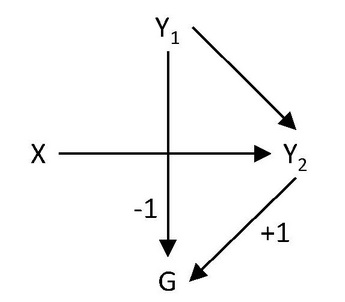

*Fig.1b: DAG of the RCT model with change score included*

### 2.1.1 Simulate data

We first need to simulate X (treatment) and Y1 (pretest). Note that in an RCT these will be unrelated (as is also clear from the DAG).

$\blacktriangleright$ Use the following code to simulate the data of an RCT.

```r
set.seed(482) # set the seed for comparison

N <- 500          # total sample size

# For Y1
mY1 <- 115    # mean on pretest
sdY1 <- 20    # sd on pretest
Y1 <- rnorm(N,mY1,sdY1)   # simulate Y1

# For X
X <- rbinom(N,1,0.5)      # simulate treatment

# For Y2
b0 <- 70          # intercept
b1 <- 20          # causal effect
b2 <- .4          # covariate effect
sdE2 <- 5         # within-group residual sd
Y2 <- b0 + b1*X + b2*Y1 + rnorm(N,0,sdE2)

dat1 <- data.frame(Y1,Y2,X)
```

$\blacktriangleright$ Consider the correlations between Y1, Y2, and X; what can you say about these?

```r
round(cor(dat1),3)
```

```
##       Y1    Y2     X
## Y1 1.000 0.635 0.019
## Y2 0.635 1.000 0.703
## X  0.019 0.703 1.000
```

### 2.1.2 Plot the data

Now we will make plots of the data like the ones used in the lecture (and the literature).

$\blacktriangleright$ First create a scatter plot with Y1 on the x-axis and Y2 on the y-axis, and with separate colors for the two treatment groups. Indicate for all the parameters defined above (mY1, sdY1, b0, b1, b2, sdE2) what feature in the plot they represent.

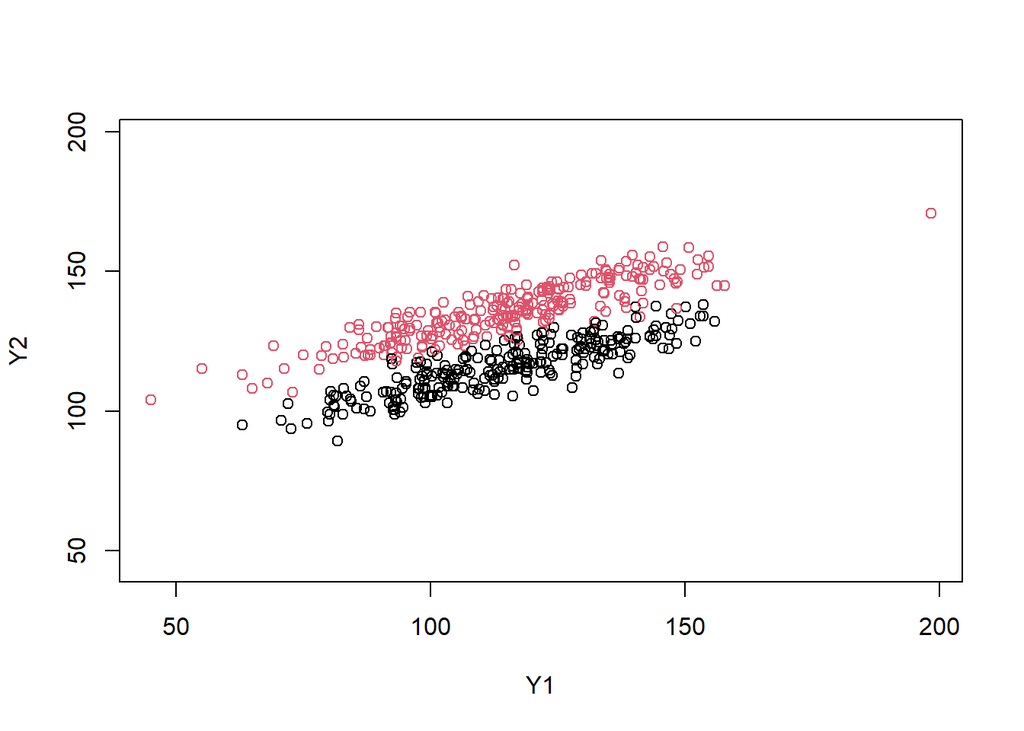

```r
# For plotting it may be useful to find the overall minimum
# and maximum across the pretest and posttest, to make the two
# axes comparable
minY <- min(c(Y1,Y2))
maxY <- max(c(Y1,Y2))

plot(x=dat1$Y1, y=dat1$Y2, col = (dat1$X+1),
        xlim=c(minY,maxY),ylim=c(minY,maxY),
        xlab="Y1", ylab="Y2")
```

$\blacktriangleright$ Which part of this plot is reflecting the causal effect from the ANCOVA model?

$\blacktriangleright$ Second, make a plot of the means of the pretest scores and post test scores of each group. In the plot, place the two time points on the x-axis and the means of the two groups separately at each time point on the y-axis. Connect the means that belong to the same group using a line plot, and use different colors for each group.

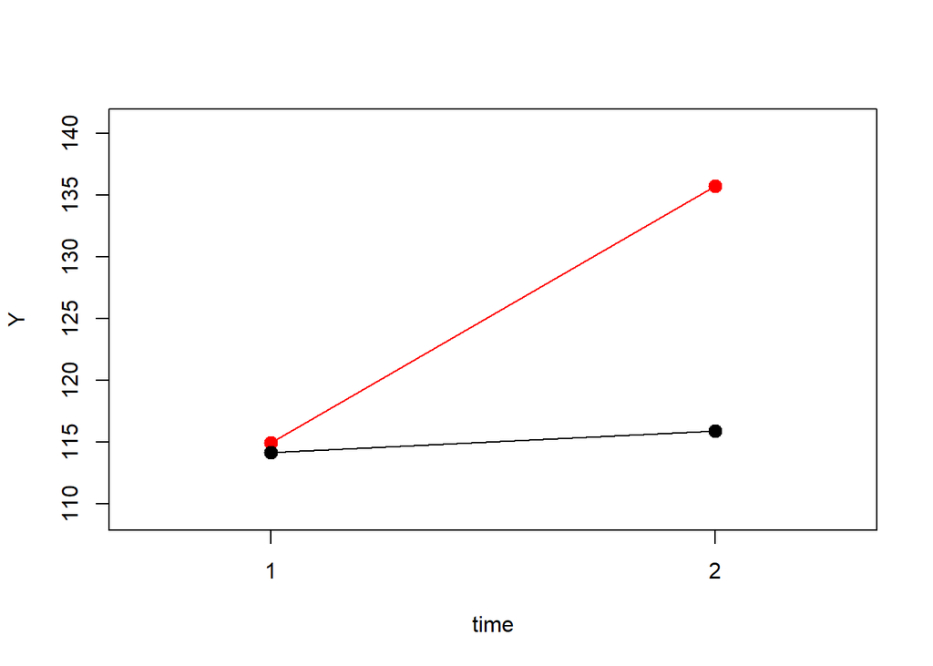

```r
# Means of:
# - pretest non-treatment group (mY10)
# - pretest treatment group (mY11)
# Note that both should be  about mY1=115 (value used in simulation)
mY10 <- mean(Y1[X==0])
mY11 <- mean(Y1[X==1])

# Means of:
# - posttest non-treatement group (mY20)
# - posttest treatment group (mY21)
# Note that the first should be about:
# mY20 = b0 + b2*mY10 = 70 + 0.4*115 = 116
# and the second should be about:
# mY21 = b0 + b1 + b2*mY11 = 70 + 20 + 0.4*115 = 136
mY20 <- mean(Y2[X==0])
mY21 <- mean(Y2[X==1])

# Gather means on both occasions per treatment condition
mYX0 <- c(mY10,mY20)
mYX1 <- c(mY11,mY21)

minY <- min(mYX0,mYX1)
maxY <- max(mYX0,mYX1)

plot(c(1,2), mYX0, type="l",
            xlim=c(0.7,2.3),
            ylim=c(minY-5,maxY+5),xaxt="n",
            xlab="time",
            ylab="Y")
lines(c(1,2),mYX1,col="red")
points(c(1,2),mYX1,pch=19,cex=1.3,col="red")
points(c(1,2),mYX0,pch=19,cex=1.3)
axis(side=1, at=seq(1, 2, by=1))
```

$\blacktriangleright$ How can this plot be used to determine whether in a change score model we would find evidence for a causal effect?

### 2.1.3 Analyze the data

Next, we analyze the data using the four models.

$\blacktriangleright$ First, estimate an ANCOVA (e.g., using the function `lm()`), with Y2 as the outcome, X as the grouping variable, and Y1 as the covariate (that is: X and Y1 are both predictors in your regression). Report the parameter (estimate, test, p-value) that is relevant for the causality question.

```r
ANCOVA <- lm(Y2 ~ X + Y1, data=dat1)
summary(ANCOVA)
```

```
##
## Call:
## lm(formula = Y2 ~ X + Y1, data = dat1)
##
## Residuals:
##     Min      1Q  Median      3Q     Max
## -13.368  -3.164  -0.228   3.411  15.822
##
## Coefficients:
##             Estimate Std. Error t value Pr(>|t|)
## (Intercept) 66.83802    1.26455   52.85   <2e-16 ***
## X           19.50102    0.43838   44.48   <2e-16 ***
## Y1           0.42946    0.01074   40.00   <2e-16 ***
## ---
## Signif. codes:  0 '***' 0.001 '**' 0.01 '*' 0.05 '.' 0.1 ' ' 1
##
## Residual standard error: 4.9 on 497 degrees of freedom
## Multiple R-squared:  0.8801, Adjusted R-squared:  0.8796
## F-statistic:  1824 on 2 and 497 DF,  p-value: < 2.2e-16
```

$\blacktriangleright$ Second, estimate an ANCOVA with the gain score (i.e., Y2-Y1) as the outcome variable, X as the grouping variable and Y1 as the covariate (that is: X and Y1 as predictors). Compare the results regarding the estimated causal effect of X from this model to those obtained above.

```r
ANCOVA <- lm((Y2-Y1) ~ X + Y1, data=dat1)
summary(ANCOVA)
```

```
##
## Call:
## lm(formula = (Y2 - Y1) ~ X + Y1, data = dat1)
##
## Residuals:
##     Min      1Q  Median      3Q     Max
## -13.368  -3.164  -0.228   3.411  15.822
##
## Coefficients:
##             Estimate Std. Error t value Pr(>|t|)
## (Intercept) 66.83802    1.26455   52.85   <2e-16 ***
## X           19.50102    0.43838   44.48   <2e-16 ***
## Y1          -0.57054    0.01074  -53.14   <2e-16 ***
## ---
## Signif. codes:  0 '***' 0.001 '**' 0.01 '*' 0.05 '.' 0.1 ' ' 1
##
## Residual standard error: 4.9 on 497 degrees of freedom
## Multiple R-squared:  0.9046, Adjusted R-squared:  0.9042
## F-statistic:  2356 on 2 and 497 DF,  p-value: < 2.2e-16
```

$\blacktriangleright$ Third, estimate the change score model, by regressing the gain score (i.e., Y2-Y1) on X; note this is a regression model with the gain score as the outcome, and only treatment X as its predictor (it may also be recognized by some as an ANOVA on the gain score). Report the parameter (estimate, test, p-value) that is relevant for the causality question.

```r
CSA <- lm((Y2-Y1) ~ X, data=dat1)
summary(CSA)
```

```
##
## Call:
## lm(formula = (Y2 - Y1) ~ X, data = dat1)
##
## Residuals:
##     Min      1Q  Median      3Q     Max
## -48.265  -8.378  -0.492   8.649  39.228
##
## Coefficients:
##             Estimate Std. Error t value Pr(>|t|)
## (Intercept)   1.7270     0.8066   2.141   0.0328 *
## X            19.0498     1.1318  16.832   <2e-16 ***
## ---
## Signif. codes:  0 '***' 0.001 '**' 0.01 '*' 0.05 '.' 0.1 ' ' 1
##
## Residual standard error: 12.65 on 498 degrees of freedom
## Multiple R-squared:  0.3626, Adjusted R-squared:  0.3613
## F-statistic: 283.3 on 1 and 498 DF,  p-value: < 2.2e-16
```

$\blacktriangleright$ Fourth, estimate the marginal model in which Y2 is regressed on X (hence, Y1 is not included in any way). Report the parameter (estimate, test, p-value) that is relevant for the causal question.

```r
Y2onX <- lm((Y2) ~ X, data=dat1)
summary(Y2onX)
```

```
##
## Call:
## lm(formula = (Y2) ~ X, data = dat1)
##
## Residuals:
##     Min      1Q  Median      3Q     Max
## -31.699  -7.331  -0.099   7.600  35.119
##
## Coefficients:
##             Estimate Std. Error t value Pr(>|t|)
## (Intercept) 115.8487     0.6410  180.73   <2e-16 ***
## X            19.8407     0.8993   22.06   <2e-16 ***
## ---
## Signif. codes:  0 '***' 0.001 '**' 0.01 '*' 0.05 '.' 0.1 ' ' 1
##
## Residual standard error: 10.05 on 498 degrees of freedom
## Multiple R-squared:  0.4943, Adjusted R-squared:  0.4932
## F-statistic: 486.7 on 1 and 498 DF,  p-value: < 2.2e-16
```

### 2.1.4 Conclusion

When comparing the results, what is your conclusion about the causal effect of treatment on the outcome?

| Model | Equation | Causal parameter | Estimate (SE) | p-value |
| --- | --- | --- | --- | --- |
| ANCOVA | $Y_{2i} = \beta_0 + \beta_1 X_i + \beta_2 Y_{1i} + e_i$ | $\beta_1$ | 19.50 (0.44) | <0.0001 |
| ANCOVA on change score | $Y_{2i} - Y_{1i} = \beta_0 + \beta_1 X_i + (\beta_2-1) Y_{1i} + e_i$ | $\beta_1$ | 19.50 (0.44) | <0.0001 |
| Change score analysis | $Y_{2i} - Y_{1i} = \gamma_0 + \gamma_1 X_i + e_i$ | $\gamma_1$ | 19.05 (1.13) | <0.0001 |
| Marignal analysis | $Y_{2i} = \phi_0 + \phi_1 X_i + e_i$ | $\phi_1$ | 19.84 (0.90) | <0.0001 |

First, we see that doing an ANCOVA with the post-test (Y2) and an ANCOVA with the gain score (Y2-Y1) as the outcome both lead to the exact same estimate of the causal effect. This is in agreement with the expressions for the ANCOVA model that we found in the lecture.

Second, the other two approaches (change score analysis, and marginal model), lead to slightly different estimates (from the ANCOVA and each other). But the substantive conclusions are all the same. This is because Y1 and X are unrelated (as would be the case in an RCT due to random assignment).

## 2.2 Existing treatment groups

A second scenario that we consider, is when there are pre-existing treatment groups. One possible example of such a scenario is the one described by Lord, where the groups were male versus female students.

[figure not shown]

[figure not shown]

### 2.2.1 Simulate data

Again, to simulate Y2, we make use of the regression model: $Y_{2i} = b_0 + b_1 X_i + b_2 Y_{1i} + e_{2i}.$

However, Y1 is now simulated in a different way: Its values will depend on X.

$\blacktriangleright$ Simulate the data using the code below.

```r
set.seed(268) # set the seed for comparison

N <- 500          # total sample size

# For X:
X <- rbinom(N,1,0.5)  # simulate treatment

# For Y1:
mY10.true <- 100      # mean of non-treatment group at pretest
mY11.true <- 130      # mean of treatment group at pretest
sdY1 <- 15            # within-group sd at pretest (both groups)

# Note that when X=1, the first part will be zero; if X=0, the second
# part is zero; so this ensures that for each individual only one part
# remains when simulating Y1:
Y1 <- (1-X)*rnorm(N, mY10.true, sdY1) + X*rnorm(N, mY11.true, sdY1)

# As a result, the two groups now have different means (mY10, mY11) on the pretest.

# For Y2:
b0 <- 70          # intercept
b1 <- 20          # causal effect
b2 <- .4          # covariate effect
sdE2 <- 5         # within-group residual sd

Y2 <- b0 + b1*X + b2*Y1 + rnorm(N,0,sdE2)

dat2 <- data.frame(Y1,Y2,X)
```

$\blacktriangleright$ Look at the correlations between X, Y1 and Y2; what can you say about these?

```r
round(cor(dat2),3)
```

```
##       Y1    Y2     X
## Y1 1.000 0.873 0.725
## Y2 0.873 1.000 0.904
## X  0.725 0.904 1.000
```

### 2.2.2 Plot the data

We will consider the same two kind of plots (scatterplot with regression lines, and plot of group means at both measurement occasions).

$\blacktriangleright$ First, plot the post-test Y2 against the pre-test Y1. Use different colors for the two groups. What part of this plot informs you on whether there is evidence for a causal effect when using the ANCOVA model?

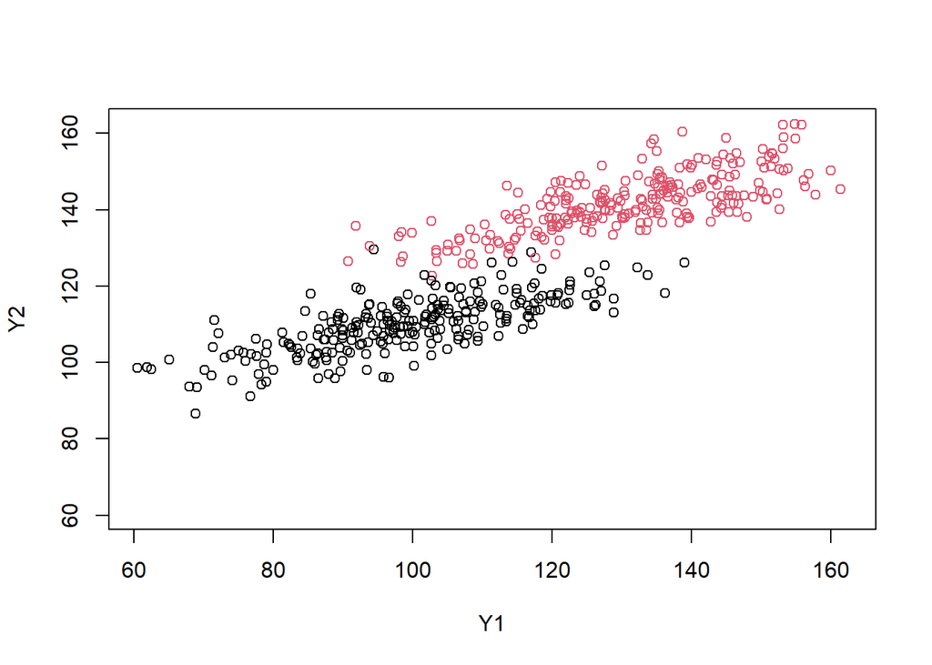

```r
minY <- min(c(Y1,Y2))
maxY <- max(c(Y1,Y2))
plot(x=dat2$Y1, y=dat2$Y2, col = (dat2$X+1),
    xlim=c(minY,maxY),ylim=c(minY,maxY),
    xlab="Y1", ylab="Y2")
```

$\blacktriangleright$ Second, make a plot in which you have the two time points on the x-axis and the means of the two groups separately (i.e., the plot related to the changes score approach). How can this plot be used to determine whether a change score analysis would provide evidence for a causal effect?

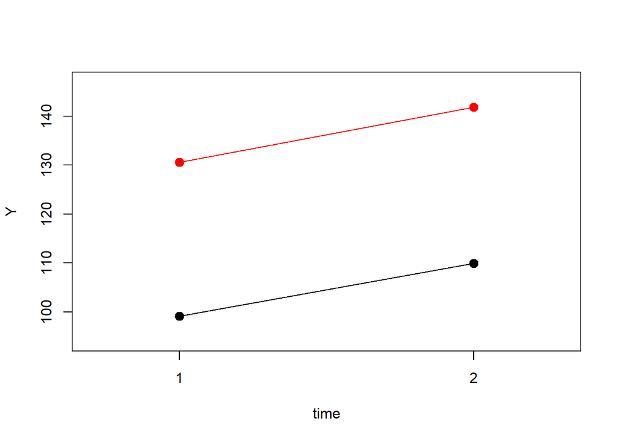

```r
# Means of:
# - pretest non-treatment group (mY01)
# - pretest treatment group (mY11)
mY10 <- mean(Y1[X==0])
mY11 <- mean(Y1[X==1])

# Means of:
# - posttest non-treatement group (mY20)
# - posttest treatment group (mY21)
mY20 <- mean(Y2[X==0])
mY21 <- mean(Y2[X==1])

# Gather means on both occasions per treatment condition
mYX0 <- c(mY10,mY20)
mYX1 <- c(mY11,mY21)

minY <- min(mYX0,mYX1)
maxY <- max(mYX0,mYX1)

plot(c(1,2), mYX0, type="l",
            xlim=c(0.7,2.3),
            ylim=c(minY-5,maxY+5),xaxt="n",
            xlab="time",
            ylab="Y")
lines(c(1,2),mYX1,col="red")
points(c(1,2),mYX1,pch=19,cex=1.3,col="red")
points(c(1,2),mYX0,pch=19,cex=1.3)
axis(side=1, at=seq(1, 2, by=1))
```

### 2.2.3 Analyze the data

Again, we analyze the data with four models.

$\blacktriangleright$ First, estimate the ANCOVA with Y2 as the outcome, and X and Y1 as the predictors. Report the parameters (estimate, test, p-value) that are relevant for the causality question.

```r
ANCOVA <- lm(Y2 ~ X + Y1, data=dat2)
summary(ANCOVA)
```

```
##
## Call:
## lm(formula = Y2 ~ X + Y1, data = dat2)
##
## Residuals:
##      Min       1Q   Median       3Q      Max
## -12.9743  -3.3461  -0.1449   3.0778  21.4051
##
## Coefficients:
##             Estimate Std. Error t value Pr(>|t|)
## (Intercept) 72.90937    1.55533   46.88   <2e-16 ***
## X           20.22580    0.66666   30.34   <2e-16 ***
## Y1           0.37341    0.01534   24.34   <2e-16 ***
## ---
## Signif. codes:  0 '***' 0.001 '**' 0.01 '*' 0.05 '.' 0.1 ' ' 1
##
## Residual standard error: 5.135 on 497 degrees of freedom
## Multiple R-squared:  0.9163, Adjusted R-squared:  0.916
## F-statistic:  2721 on 2 and 497 DF,  p-value: < 2.2e-16
```

$\blacktriangleright$ Second, estimate the ANCOVA on on the gain score (i.e., Y2-Y1), with X and Y1 as the predictors. Compare the results to the results obtained with an ANCOVA on Y2.

```r
ANCOVA.CS <- lm((Y2-Y1) ~ X + Y1, data=dat2)
summary(ANCOVA.CS)
```

```
##
## Call:
## lm(formula = (Y2 - Y1) ~ X + Y1, data = dat2)
##
## Residuals:
##      Min       1Q   Median       3Q      Max
## -12.9743  -3.3461  -0.1449   3.0778  21.4051
##
## Coefficients:
##             Estimate Std. Error t value Pr(>|t|)
## (Intercept) 72.90937    1.55533   46.88   <2e-16 ***
## X           20.22580    0.66666   30.34   <2e-16 ***
## Y1          -0.62659    0.01534  -40.84   <2e-16 ***
## ---
## Signif. codes:  0 '***' 0.001 '**' 0.01 '*' 0.05 '.' 0.1 ' ' 1
##
## Residual standard error: 5.135 on 497 degrees of freedom
## Multiple R-squared:  0.7705, Adjusted R-squared:  0.7696
## F-statistic: 834.4 on 2 and 497 DF,  p-value: < 2.2e-16
```

$\blacktriangleright$ Third, estimate the change score model by regressing the gain score (Y2-Y1) on X. Report the parameter (estimate, test, p-value) that is relevant for the causality question.

```r
CSA <- lm((Y2-Y1) ~ X, data=dat2)
summary(CSA)
```

```
##
## Call:
## lm(formula = (Y2 - Y1) ~ X, data = dat2)
##
## Residuals:
##     Min      1Q  Median      3Q     Max
## -28.831  -6.951   0.476   7.137  32.663
##
## Coefficients:
##             Estimate Std. Error t value Pr(>|t|)
## (Intercept)  10.7877     0.6757  15.964   <2e-16 ***
## X             0.4922     0.9576   0.514    0.607
## ---
## Signif. codes:  0 '***' 0.001 '**' 0.01 '*' 0.05 '.' 0.1 ' ' 1
##
## Residual standard error: 10.71 on 498 degrees of freedom
## Multiple R-squared:  0.0005302,  Adjusted R-squared:  -0.001477
## F-statistic: 0.2642 on 1 and 498 DF,  p-value: 0.6075
```

$\blacktriangleright$ Fourth, estimate the marginal model by regressing Y2 on X. Report the parameter (estimate, test, p-value) that is relevant for the causality question.

```r
Y2onX <- lm(Y2 ~ X, data=dat2)
summary(Y2onX)
```

```
##
## Call:
## lm(formula = Y2 ~ X, data = dat2)
##
## Residuals:
##      Min       1Q   Median       3Q      Max
## -23.3303  -4.9666   0.0988   5.0648  20.4291
##
## Coefficients:
##             Estimate Std. Error t value Pr(>|t|)
## (Intercept) 109.9308     0.4793  229.33   <2e-16 ***
## X            31.9861     0.6793   47.09   <2e-16 ***
## ---
## Signif. codes:  0 '***' 0.001 '**' 0.01 '*' 0.05 '.' 0.1 ' ' 1
##
## Residual standard error: 7.594 on 498 degrees of freedom
## Multiple R-squared:  0.8166, Adjusted R-squared:  0.8162
## F-statistic:  2217 on 1 and 498 DF,  p-value: < 2.2e-16
```

### 2.2.4 Conclusion

When comparing the results, what is your conclusion about the causal effect of treatment on the outcome, and what model should be preferred?

| Model | Equation | Causal parameter | Estimate (SE) | p-value |
| --- | --- | --- | --- | --- |
| ANCOVA | $Y_{2i} = \beta_0 + \beta_1 X_i + \beta_2 Y_{1i} + e_i$ | $\beta_1$ | 20.23 (0.67) | 0.0001 |
| ANCOVA on change score | $Y_{2i} - Y_{1i} = \beta_0 + \beta_1 X_i + (\beta_2-1) Y_{1i} + e_i$ | $\beta_1$ | 20.23 (0.67) | 0.0001 |
| Change score analysis | $Y_{2i} - Y_{1i} = \gamma_0 + \gamma_1 X_i + e_i$ | $\gamma_1$ | 0.49 (0.96) | 0.61 |
| Marignal analysis | $Y_{2i} = \phi_0 + \phi_1 X_i + e_i$ | $\phi_1$ | 31.99 (0.68) | 0.0001 |

Clearly, the two ANCOVAs lead to the same estimate of the causal effect; it is estimated to be about 20, which is the parameter used in the regression equation to simulate the data.

In contrast, the change score model is leading to the conclusion that treatment has no effect, while the marginal model (Y2 regressed on X) results in a causal effect of about 30.

Based on the DAGs, we know that X has a direct effect on Y2, which is obtained with the ANCOVA approach. But there is also an indirect effect, as X affects Y1 which in turn affects Y2 (for the sake of completeness, the latter is equal to b2*(mY11-mY01)).

The marginal model is helping us to estimate that. Hence, if we are interested in the total causal effect of X on Y2, we should consider the last model. But we can add also the estimate of the direct effect, to make the story richer.

## 2.3 Assignment excl. based on pre-test

In the previous scenario, we started with creating different groups and then simulated the pre-test. Here, we will start with creating a pretest score Y1, and then create two groups X. The groups will be based on a mean-split, and are thus *fully determined* by the pre-test score.

An example of such a scenario is when people do a test (e.g., a test of their soccer skills), and all indiduals that score above a certain threshold are then given the treatment (i.e., assigned to X=1, which consists of two additional training sessions per week), whereas the people who score below the threshold are not (i.e., they are assigned to X=0); then, at the end of the year, you measure them agian (i.e., their soccer skills), and you want to determine whether the treatment (additional trainings) had a beneficial effect.

The DAG of this scenario looks like this:

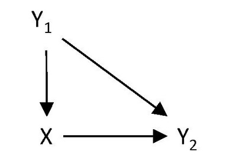

Fig.3a: DAG of groups based on pre-test score

The DAG can be extended with the gain score in it to look like this:

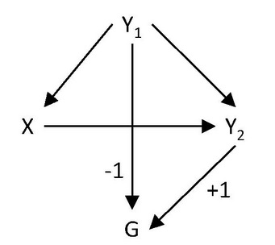

Fig.3b: DAG of groups based on pre-test score

### 2.3.1 Simulate data

We start with simulating the data. For this, we first need to simulate Y1, which then determines X. Then we can simulate Y2. To make it comparable to the previous example, we use the mean and standard deviation from the Y1 in the previous scenario.Furthermore, when creating Y2, we will make use of the same b0, b1, b2 and residual standard deviation as in the scenario above.

$\blacktriangleright$ Use the following code to simulate the data.

```r
sd.pre <- sd(Y1)                  # determine total sd of Y1 in simulations above
mean.pre <- mean(Y1)            # determine total mean of Y1 in sims above

# create a new pre-test score with the same mean and variance
Y1 <- rnorm(N,mean.pre,sd.pre)

# Use a mean split for Y1 to create two groups:
X <- rep(0,N)
X [Y1>mean(Y1)] <- 1        # Treatment groups based on mean split of pretest

# Simulate Y2
Y2 <- b0 + b1*X + b2*Y1 + rnorm(N,0,sdE2)

dat3 <- data.frame(Y1,Y2,X)
```

### 2.3.2 Plot the data

$\blacktriangleright$ First, make the pre-post test plot again and describe what this teaches us.

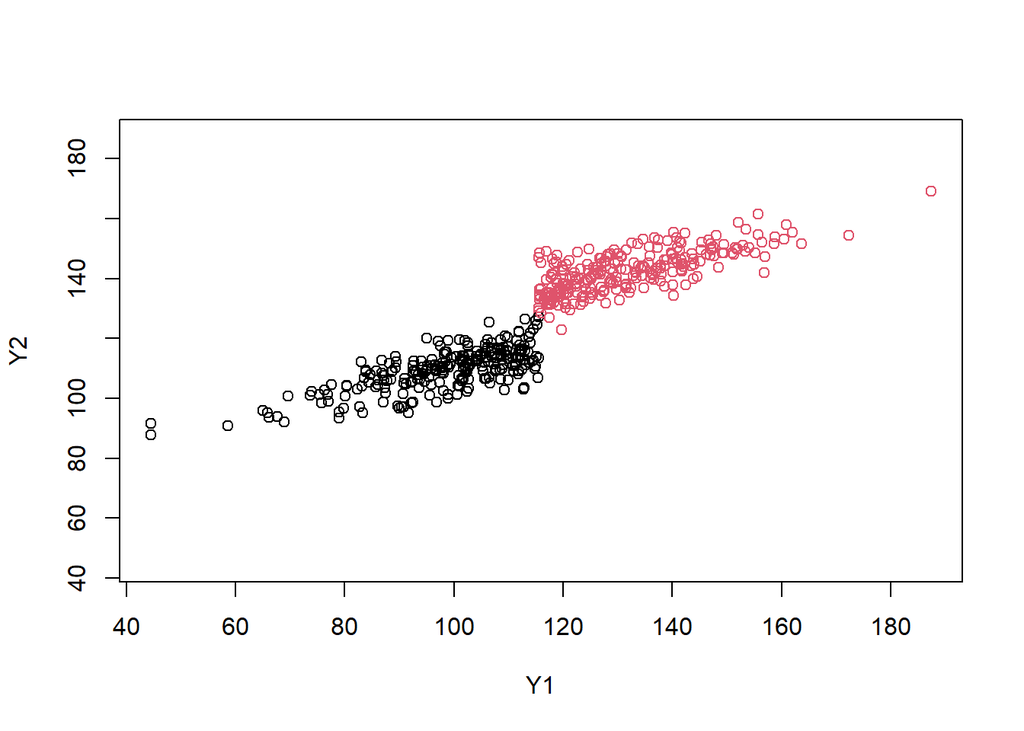

```r
minY <- min(c(Y1,Y2))
maxY <- max(c(Y1,Y2))
plot(x=dat3$Y1, y=dat3$Y2, col = (dat3$X+1),
    xlim=c(minY,maxY),ylim=c(minY,maxY),
    xlab="Y1", ylab="Y2")
```

$\blacktriangleright$ Second, make the plot of the means.

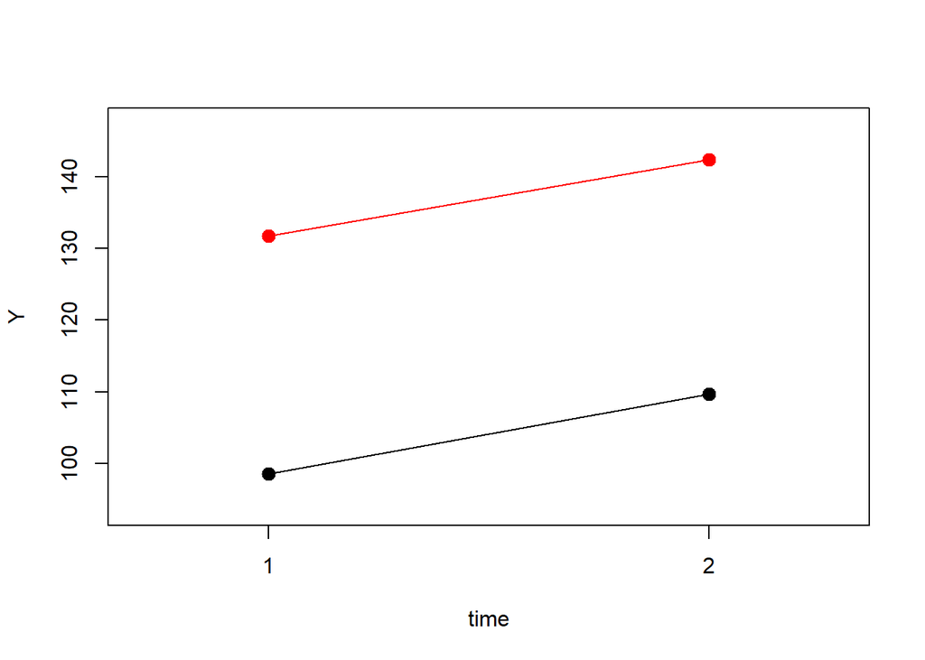

```r
# Determine means at each occasion for each group
mY10 <- mean(Y1[X==0])
mY11 <- mean(Y1[X==1])
mY20 <- mean(Y2[X==0])
mY21 <- mean(Y2[X==1])

# Gather means on both occasions per treatment condition
mY0 <- c(mY10,mY20)
mY1 <- c(mY11,mY21)

minY <- min(mY0,mY1)
maxY <- max(mY0,mY1)

plot(c(1,2), mY0, type="l",
            xlim=c(0.7,2.3),
            ylim=c(minY-5,maxY+5),xaxt="n",
            xlab="time",
            ylab="Y")
lines(c(1,2),mY1,col="red")
points(c(1,2),mY1,pch=19,cex=1.3,col="red")
points(c(1,2),mY0,pch=19,cex=1.3)
axis(side=1, at=seq(1, 2, by=1))
```

### 2.3.3 Analyze the data

$\blacktriangleright$ First, estimate the ANCOVA model with Y2 as the outcome, and X and Y1 as its predictors. What conclusion can you draw about the causal effect based on this analysis?

```r
ANCOVA <- lm(Y2 ~ X + Y1, data=dat3)
summary(ANCOVA)
```

```
##
## Call:
## lm(formula = Y2 ~ X + Y1, data = dat3)
##
## Residuals:
##      Min       1Q   Median       3Q      Max
## -14.6433  -3.1055   0.1386   2.9358  12.8257
##
## Coefficients:
##             Estimate Std. Error t value Pr(>|t|)
## (Intercept) 69.39985    1.72669   40.19   <2e-16 ***
## X           19.23627    0.71780   26.80   <2e-16 ***
## Y1           0.40816    0.01723   23.69   <2e-16 ***
## ---
## Signif. codes:  0 '***' 0.001 '**' 0.01 '*' 0.05 '.' 0.1 ' ' 1
##
## Residual standard error: 4.862 on 497 degrees of freedom
## Multiple R-squared:  0.9261, Adjusted R-squared:  0.9258
## F-statistic:  3116 on 2 and 497 DF,  p-value: < 2.2e-16
```

$\blacktriangleright$ Second, estimate the ANCOVA with teh gain score Y2-Y1 as the outcome and Y1 and X as the predictors. What conclusion can you draw about the causal effect based on this analysis?

```r
ANCOVA.CS <- lm((Y2-Y1) ~ X + Y1, data=dat3)
summary(ANCOVA.CS)
```

```
##
## Call:
## lm(formula = (Y2 - Y1) ~ X + Y1, data = dat3)
##
## Residuals:
##      Min       1Q   Median       3Q      Max
## -14.6433  -3.1055   0.1386   2.9358  12.8257
##
## Coefficients:
##             Estimate Std. Error t value Pr(>|t|)
## (Intercept) 69.39985    1.72669   40.19   <2e-16 ***
## X           19.23627    0.71780   26.80   <2e-16 ***
## Y1          -0.59184    0.01723  -34.34   <2e-16 ***
## ---
## Signif. codes:  0 '***' 0.001 '**' 0.01 '*' 0.05 '.' 0.1 ' ' 1
##
## Residual standard error: 4.862 on 497 degrees of freedom
## Multiple R-squared:  0.7037, Adjusted R-squared:  0.7025
## F-statistic: 590.2 on 2 and 497 DF,  p-value: < 2.2e-16
```

$\blacktriangleright$ Third, estimate the change score model by regressing Y2-Y1 on X. What conclusion can you draw based on this analysis?

```r
CSA <- lm((Y2-Y1) ~ X, data=dat3)
summary(CSA)
```

```
##
## Call:
## lm(formula = (Y2 - Y1) ~ X, data = dat3)
##
## Residuals:
##     Min      1Q  Median      3Q     Max
## -28.913  -5.955  -0.023   5.850  35.935
##
## Coefficients:
##             Estimate Std. Error t value Pr(>|t|)
## (Intercept)  11.0677     0.5711  19.378   <2e-16 ***
## X            -0.3735     0.7982  -0.468     0.64
## ---
## Signif. codes:  0 '***' 0.001 '**' 0.01 '*' 0.05 '.' 0.1 ' ' 1
##
## Residual standard error: 8.921 on 498 degrees of freedom
## Multiple R-squared:  0.0004395,  Adjusted R-squared:  -0.001568
## F-statistic: 0.219 on 1 and 498 DF,  p-value: 0.64
```

$\blacktriangleright$ Fourth, estimate the marginal model with Y2 as the outcome and X as the predictor. What conclusion can you draw based on this analysis?

```r
Y2onX <- lm(Y2 ~ X, data=dat3)
summary(Y2onX)
```

```
##
## Call:
## lm(formula = Y2 ~ X, data = dat3)
##
## Residuals:
##      Min       1Q   Median       3Q      Max
## -21.7100  -5.0590   0.2801   4.8511  26.7645
##
## Coefficients:
##             Estimate Std. Error t value Pr(>|t|)
## (Intercept) 109.6276     0.4537  241.63   <2e-16 ***
## X            32.7598     0.6341   51.67   <2e-16 ***
## ---
## Signif. codes:  0 '***' 0.001 '**' 0.01 '*' 0.05 '.' 0.1 ' ' 1
##
## Residual standard error: 7.087 on 498 degrees of freedom
## Multiple R-squared:  0.8428, Adjusted R-squared:  0.8425
## F-statistic:  2669 on 1 and 498 DF,  p-value: < 2.2e-16
```

### 2.3.4 Conclusion

When comparing the results, what is your conclusion about the causal effect of X, and which analysis should be preferred?

| Model | Equation | Causal parameter | Estimate (SE) | p-value |
| --- | --- | --- | --- | --- |
| ANCOVA | $Y_{2i} = \beta_0 + \beta_1 X_i + \beta_2 Y_{1i} + e_i$ | $\beta_1$ | 19.24 (0.72) | <0.0001 |
| ANCOVA on change score | $Y_{2i} - Y_{1i} = \beta_0 + \beta_1 X_i + (\beta_2-1) Y_{1i} + e_i$ | $\beta_1$ | 19.24 (0.72) | <0.0001 |
| Change score analysis | $Y_{2i} - Y_{1i} = \gamma_0 + \gamma_1 X_i + e_i$ | $\gamma_1$ | -0.37 (0.80) | 0.64 |
| Marignal analysis | $Y_{2i} = \phi_0 + \phi_1 X_i + e_i$ | $\phi_1$ | 32.76 (0.63) | 0.0001 |

Again, the first two models (ANCOVA and ANCOVA on the change score) lead to the exact same estimate. The other two models lead to different estimates: the third model leads to the conclusion that there is no causal effect, whereas the last model leads to the conclusion that there is a larger positive effect than that obtained with the ANCOVA model. In fact, these results are very similar to the results we obtained with the data in the previous scenario, which illustrates that they are not so informative by themselves.

To decide which analysis is informative if we are interested in obtaining an estimate of the ACE, we should use the DAGs: then, we would conclude that the ANCOVA model is the correct approach here, because Y1 is a confounder (X <- Y1 -> Y2) for which we need to adjust. Note however that it is a very specific scenario, in which there is no overlap between the groups on the covariate (which, btw, would be considered a violation of positivity in the Rubin causal framework!).

## 2.4 Assignment partly based on pre-test

In the previous scenario, we created different groups using a cut-off for the pre-test. As a result, there was no overlap between the groups on the pretest, which was clearly visible in the first plot (Y2 plotted against Y1) that we made.

Now, we will create data in which the group assignment is only *partly* based on the pre-test score. Hence, there should be partial overlap between the two groups on the pre-test. The DAGs for this scenario are the same as the ones for the previous scenario.

### 2.4.1 Simulate data

We start again with creating the pre-test score as we did in the previous scenario. Then we use this variable to assign people to one of two treatment conditions, but now the assignment is not deterministic: There should be overlap between the groups on the pretest score.

$\blacktriangleright$ We do this using a logistic regression model, using the following code:

```r
Y1 <- rnorm(N, mean.pre, sd.pre)  # pre-test

# To create a treatment variable based on this pretest
# but the probability of being treated only partly depends on the pretest
z <- 0.15*(Y1-mean(Y1))           # linear combination
pr <- 1/(1+exp(-z))               # pass through an inv-logit function
X <- rbinom(N,1,pr)               # Bernoulli treatment variable

# Now we can create the post-test, like we have done before
Y2 <- b0 + b1*X + b2*Y1 + rnorm(N,0,sdE2)

dat4 <- data.frame(Y1,Y2,X)
```

### 2.4.2 Plot the data

$\blacktriangleright$ First, make the pre-post test plot.

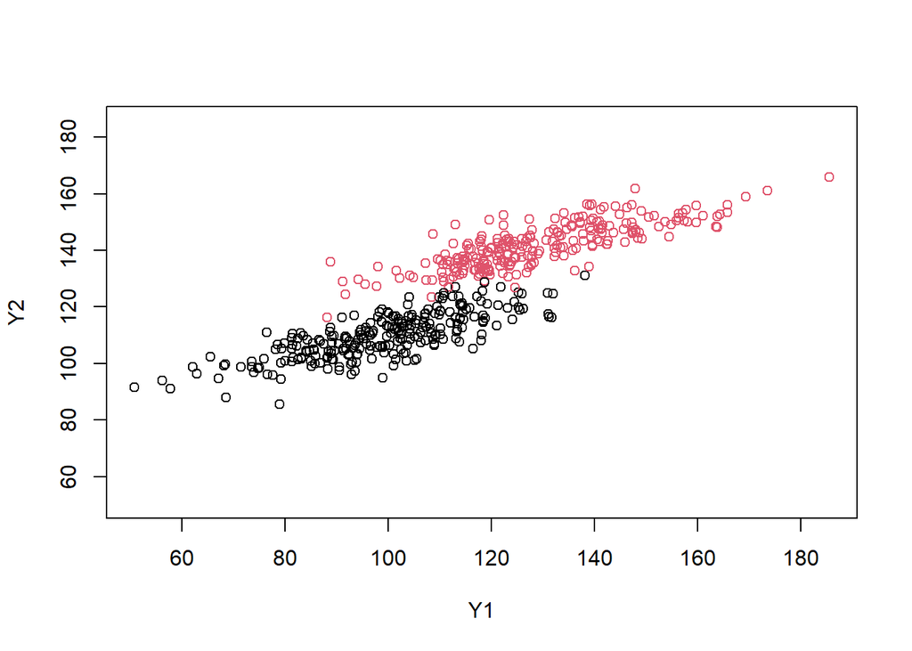

```r
minY <- min(c(Y1,Y2))
maxY <- max(c(Y1,Y2))
plot(x=dat4$Y1, y=dat4$Y2, col = (dat4$X+1),
    xlim=c(minY,maxY),ylim=c(minY,maxY),
    xlab="Y1", ylab="Y2")
```

$\blacktriangleright$ Second, make a plot of the means.

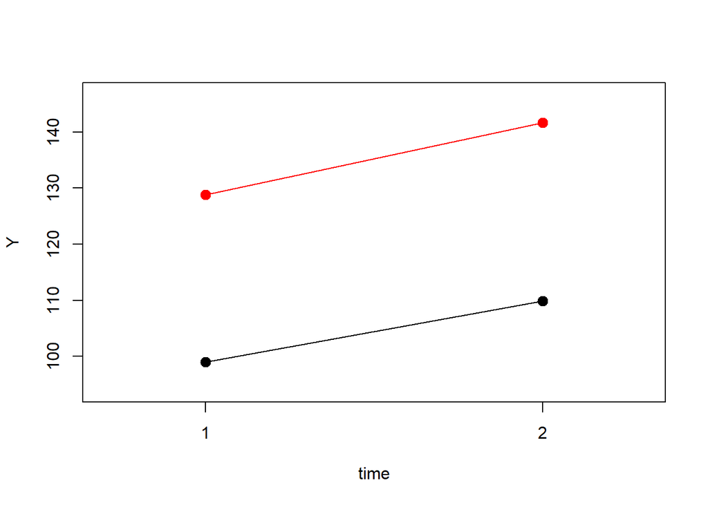

```r
# Compute means at first and second occasion
mY10 <- mean(Y1[X==0])
mY11 <- mean(Y1[X==1])
mY20 <- mean(Y2[X==0])
mY21 <- mean(Y2[X==1])

# Gather means on both occasions per treatment condition
mY0 <- c(mY10,mY20)
mY1 <- c(mY11,mY21)

minY <- min(mY0,mY1)
maxY <- max(mY0,mY1)

plot(c(1,2), mY0, type="l",
            xlim=c(0.7,2.3),
            ylim=c(minY-5,maxY+5),xaxt="n",
            xlab="time",
            ylab="Y")
lines(c(1,2),mY1,col="red")
points(c(1,2),mY1,pch=19,cex=1.3,col="red")
points(c(1,2),mY0,pch=19,cex=1.3)
axis(side=1, at=seq(1, 2, by=1))
```

### 2.4.3 Analyze the data

$\blacktriangleright$ First, estimate the ANCOVA with Y2 as the outcome, and X and Y1 as its predictors. What conclusion can you draw about the causal effect based on this analysis?

```r
ANCOVA <- lm(Y2 ~ X + Y1, data=dat4)
summary(ANCOVA)
```

```
##
## Call:
## lm(formula = Y2 ~ X + Y1, data = dat4)
##
## Residuals:
##      Min       1Q   Median       3Q      Max
## -16.2914  -3.3854   0.0857   3.3269  13.7512
##
## Coefficients:
##             Estimate Std. Error t value Pr(>|t|)
## (Intercept) 70.19772    1.42827   49.15   <2e-16 ***
## X           19.88475    0.61232   32.48   <2e-16 ***
## Y1           0.40056    0.01408   28.45   <2e-16 ***
## ---
## Signif. codes:  0 '***' 0.001 '**' 0.01 '*' 0.05 '.' 0.1 ' ' 1
##
## Residual standard error: 4.986 on 497 degrees of freedom
## Multiple R-squared:  0.9223, Adjusted R-squared:  0.922
## F-statistic:  2949 on 2 and 497 DF,  p-value: < 2.2e-16
```

$\blacktriangleright$ Second, estimate the ANCOVA with Y2-Y1 as the outcome and Y1 and X as the predictors. What conclusion can you draw about the causal effect based on this analysis?

```r
ANCOVA.CS <- lm((Y2-Y1) ~ X + Y1, data=dat4)
summary(ANCOVA.CS)
```

```
##
## Call:
## lm(formula = (Y2 - Y1) ~ X + Y1, data = dat4)
##
## Residuals:
##      Min       1Q   Median       3Q      Max
## -16.2914  -3.3854   0.0857   3.3269  13.7512
##
## Coefficients:
##             Estimate Std. Error t value Pr(>|t|)
## (Intercept) 70.19772    1.42827   49.15   <2e-16 ***
## X           19.88475    0.61232   32.48   <2e-16 ***
## Y1          -0.59944    0.01408  -42.58   <2e-16 ***
## ---
## Signif. codes:  0 '***' 0.001 '**' 0.01 '*' 0.05 '.' 0.1 ' ' 1
##
## Residual standard error: 4.986 on 497 degrees of freedom
## Multiple R-squared:  0.7868, Adjusted R-squared:  0.7859
## F-statistic: 916.9 on 2 and 497 DF,  p-value: < 2.2e-16
```

$\blacktriangleright$ Third, estimate the change score model by regressing Y2-Y1 on X. What conclusion can you draw based on this analysis?

```r
CSA <- lm((Y2-Y1) ~ X, data=dat4)
summary(CSA)
```

```
##
## Call:
## lm(formula = (Y2 - Y1) ~ X, data = dat4)
##
## Residuals:
##     Min      1Q  Median      3Q     Max
## -32.394  -6.751   0.659   6.931  34.154
##
## Coefficients:
##             Estimate Std. Error t value Pr(>|t|)
## (Intercept)  10.8441     0.6712  16.156   <2e-16 ***
## X             2.0245     0.9608   2.107   0.0356 *
## ---
## Signif. codes:  0 '***' 0.001 '**' 0.01 '*' 0.05 '.' 0.1 ' ' 1
##
## Residual standard error: 10.74 on 498 degrees of freedom
## Multiple R-squared:  0.008835,   Adjusted R-squared:  0.006845
## F-statistic: 4.439 on 1 and 498 DF,  p-value: 0.03562
```

$\blacktriangleright$ Fourth, estimate the marginal model with Y2 as the outcome and X as the predictor. What conclusion can you draw based on this marginal?

```r
Y2onX <- lm(Y2 ~ X, data=dat4)
summary(Y2onX)
```

```
##
## Call:
## lm(formula = Y2 ~ X, data = dat4)
##
## Residuals:
##      Min       1Q   Median       3Q      Max
## -25.4075  -5.8867  -0.1505   6.1577  24.2936
##
## Coefficients:
##             Estimate Std. Error t value Pr(>|t|)
## (Intercept) 109.8590     0.5048  217.63   <2e-16 ***
## X            31.8193     0.7226   44.03   <2e-16 ***
## ---
## Signif. codes:  0 '***' 0.001 '**' 0.01 '*' 0.05 '.' 0.1 ' ' 1
##
## Residual standard error: 8.077 on 498 degrees of freedom
## Multiple R-squared:  0.7956, Adjusted R-squared:  0.7952
## F-statistic:  1939 on 1 and 498 DF,  p-value: < 2.2e-16
```

### 2.4.4 Conclusion

When comparing the results, what is your conclusion? How can a DAG help to decide which model to use?

| Model | Equation | Causal parameter | Estimate (SE) | p-value |
| --- | --- | --- | --- | --- |
| ANCOVA | $Y_{2i} = \beta_0 + \beta_1 X_i + \beta_2 Y_{1i} + e_i$ | $\beta_1$ | 19.88 (0.61) | <0.0001 |
| ANCOVA on change score | $Y_{2i} - Y_{1i} = \beta_0 + \beta_1 X_i + (\beta_2-1) Y_{1i} + e_i$ | $\beta_1$ | 19.88 (0.61) | <0.0001 |
| Change score analysis | $Y_{2i} - Y_{1i} = \gamma_0 + \gamma_1 X_i + e_i$ | $\gamma_1$ | 2.02 (0.96) | 0.0356 |
| Marignal analysis | $Y_{2i} = \phi_0 + \phi_1 X_i + e_i$ | $\phi_1$ | 31.82 (0.72) | 0.0001 |

Again, the two ANCOVAs (with Y2 or Y2-Y1 as the outcome) lead to the same estimate of the causal effect. The change score model (with only X as a predictor of Y2-Y1) gives a much smaller, yet significant positive effect. Finally, the marginal model (With Y2 regressed on X) results in a very large significant positive effect.

Based on the DAG, we know that Y1 is a common cause of X and Y2, and therefore we should control for it (i.e., condition on it by including it as a predictor). Hence, the two ANCOVA approaches should be preferred over the other two approaches.